# Lecture 2 code

Both examples follow the script from Kruschke, J. K. (2015). Doing Bayesian Data Analysis, Second Edition:Tutorial with R, JAGS, and Stan. Academic Press / Elsevier. Please note, in order to run this notebook you’ll need to include the files `DBDA2E-utilities.R` and `BernGrid.R` which can be found in `DBDA2Eprograms.zip` uploaded on Canvas.

# Example 1: Simulating long-run relative frequency

In this example, our goal is to simulate flipping a coin N times and compute the relative proportion of heads at each sample. A few steps in this analysis:

### Define the variables

We need to specify the number of total flips to simulate (e.g. 500). Generally, it is good practice to set a random seed so that we can replicate the experiments.

```r
# Define variables
    # Specify the total number of flips
n_flips <- 500
set.seed(1) # Set to constant random seed
```

### Generate random samples

Using the `sample()` function, we simulate the coin flipping mechanism by letting $P(H) = 0.5,$ i.e., a fair coin, repated 500 times.

```r
# Specify the total number of flips
n_flips <- 500
set.seed(1) # Set to constant random seed
# Generate a random sample
flipsequence = sample(x=c(0,1), # Sample from coin (heads=1, tails=0)
                      prob=c(.5,.5), # Define a fair coin
                      size=n_flips, # Number of flips
                      replace=TRUE ) # Sample with replacement
```

### Compute the running proportion of heads

After generating a sequence of coin flips, we can create a vector of cumulative sum to keep track of how many coins turned up as heads so far. Dividing by the total population, we get the running proportion of heads.

```r
# Compute the running proportion of heads
r = cumsum( flipsequence )
n = 1:n_flips
runprop = r / n
```

### Summarize the results

We summarize the results by plotting each trial against its cumulative results, along the graph is a snippet of the flip sequence.This shows an idea of what the experiments look like at the initial stage.

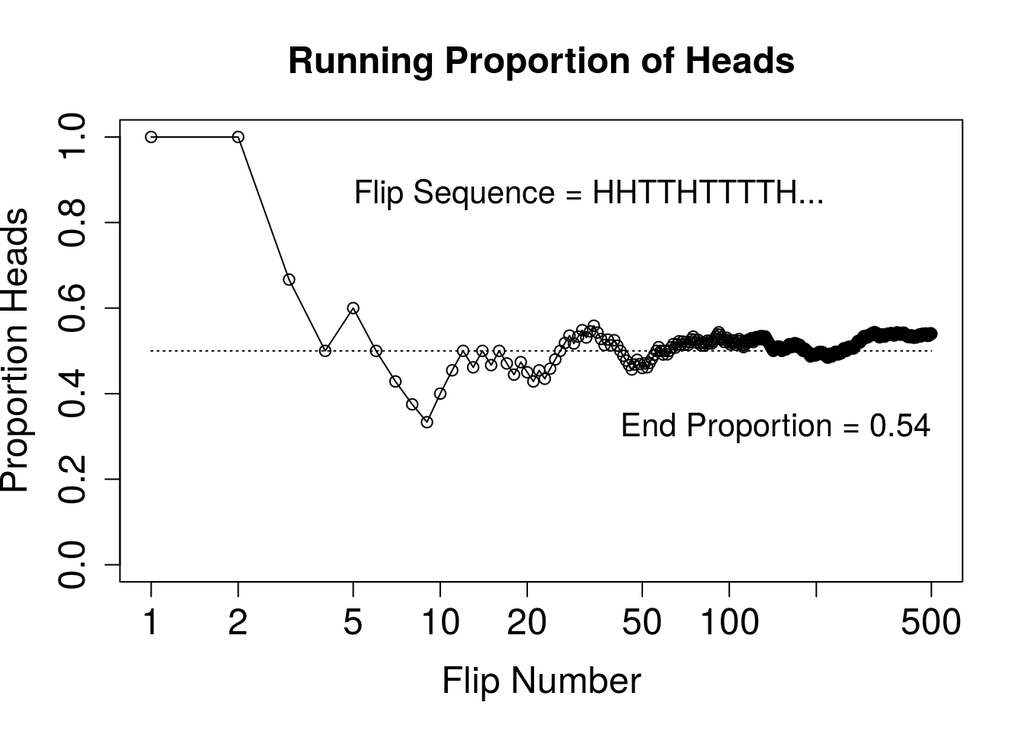

```r
# Graph the running proportion
plot( n , runprop , type="o" , log="x" ,
      xlim=c(1,n_flips) , ylim=c(0.0,1.0) , cex.axis=1.5 ,
      xlab="Flip Number" , ylab="Proportion Heads" , cex.lab=1.5 ,
      main="Running Proportion of Heads" , cex.main=1.5 )

# Plot a dotted horizontal line at y=.5, just as a reference line:
lines( c(1,n_flips) , c(.5,.5) , lty=3 )

# Display the beginning of the flip sequence. These string and character
# manipulations may seem mysterious, but you can de-mystify by unpacking
# the commands starting with the innermost parentheses or brackets and
# moving to the outermost.

flipletters = paste( c("T","H")[ flipsequence[ 1:10 ] + 1 ] , collapse="" )
displaystring = paste( "Flip Sequence = " , flipletters , "..." , sep="" )
text( 5 , .9 , displaystring , adj=c(0,1) , cex=1.3 )
# Display the relative frequency at the end of the sequence.
text(n_flips, .3 , paste("End Proportion =",runprop[n_flips]) , adj=c(1,0) , cex=1.3 )
```

# Example 2: Estimating bias of a coin flip

The idea of this example is to use Bayes’ rule to estimate the bias of a coin. Recall the Bayes’ rule is defined as
$$p(\theta|D) = \frac{p(\theta)p(D|\theta)}{p(D)}$$
. In our case, our goal is to generate the posterior distribution ($p(\theta|D)$) based on the following:

1. our initial assumption (prior distribution, $p(\theta)$)
2. the observed value - in our case - simulated data $D$
3. the likelihood function based on the data ($p(D|\theta$)

Using the function `BernGrid.R` provided in the book, we can implement this process in the following example:

```r
Theta = seq( 0 , 1 , length=10 )  # Sparse teeth for Theta.
pTheta = pmin( Theta , 1-Theta ) # Triangular shape for pTheta.
pTheta = pTheta/sum(pTheta)      # Make pTheta sum to 1.0

Data = c(rep(0,0),rep(1,1))      # Single flip with 1 head
print(Data)
```

```
## [1] 1
```

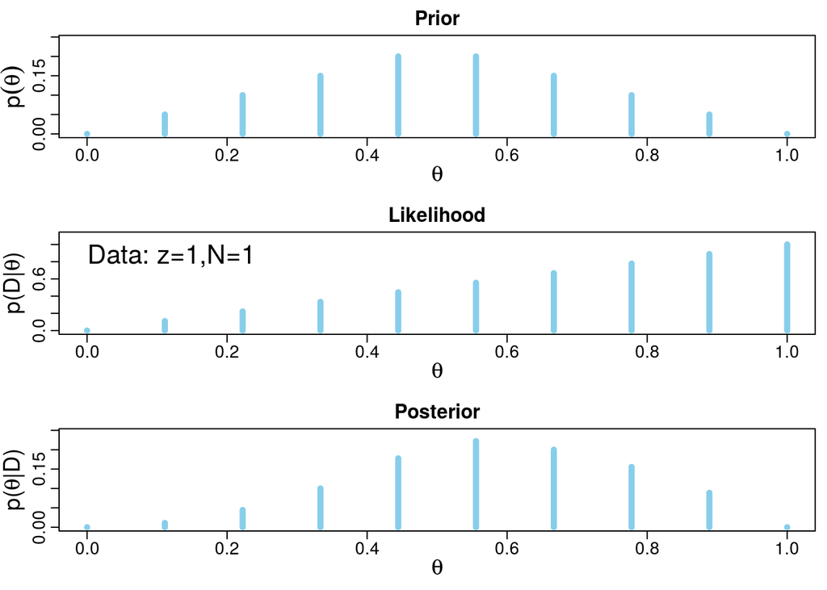

```r
posterior = BernGrid( Theta, pTheta , Data , plotType="Bars" ,
                      showCentTend="None" , showHDI=FALSE , showpD=FALSE )
```